# Informe 7: Servidor UOC Ubuntu. Puesta en marcha.

Carmen Lebrero Cia

# Introducción

Dado que nuestro espacio de RAM era demasiado reducido como para obtener todos los objetos que son necesarios para nuestro proyecto en cuanto a los datos de metilación, la UOC nos ha proporcionado un servidor Ubuntu 20.04 con características adaptadas a nuestras necesidades.

Sin embargo, nos encontramos con que el servidor no tiene instaladas los programas que hemos solicitado, por lo que tenemos que poner el servidor en marcha para seguir con nuestro trabajo. En este informe se muestra el código utilizado tanto en la consola del servidor como el código R para tener los datos listos para trabajar.

# Puesta en marcha del servidor

## Acceso al servidor

Este es un paso sencillo que realizaremos desde nuestro `cmd` de Windows. Teniendo instalado ssh y habiendo suministrado nuestra clave pública a servicios informáticos de la UOC.

`ssh carmenlc@84.88.58.67`

Para hacer más sencillas las próximas conexiones y no tener que poner la IP entera, podemos realizar unas modificaciones al archivo hosts encontrado en el path `C:\Windows\System32\drivers\etc`. Abrimos este archivo con un bloc de notas como administador y simplemente tenemos que añadir al final la IP `84.88.58.67` junto con el nombre que le queramos dar al host, en nuestro caso `uocsev` (ver Imagen adjunta). Ahora podemos entrar en el servidor utilizando el siguiente comando:

`ssh carmenlc@uocsev`

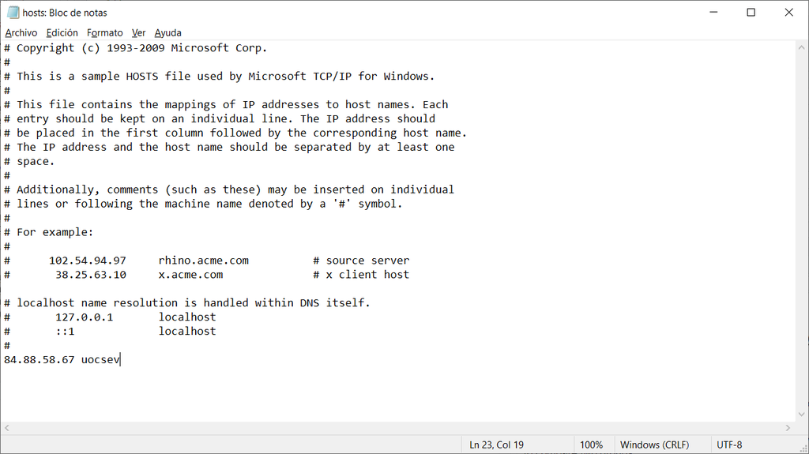

Captura de pantalla del archivo hosts modificado.

```r
knitr::include_graphics("figures/hosts.png")
```

## Instalación de programas en el servidor

Como ya se ha adelantado, el servidor estaba completamente vacío por lo que se instalaron tanto R como Anaconda.

### Instalación R

Para instalar R seguimos el siguiente procedimiento: https://www.digitalocean.com/community/tutorials/how-to-install-r-on-ubuntu-20-04-es

```
# Añadimos la clave GPG

(base) carmenlc@localhost:~$ sudo apt-key adv --keyserver keyserver.ubuntu.com --recv-keys E298A3A825C0D65DFD57CBB651716619E084DAB9

# Ahora añadimos el repositorio

(base) carmenlc@localhost:~$  sudo add-apt-repository 'deb https://cloud.r-project.org/bin/linux/ubuntu bionic-cran40/'

# Ejecutamos update para incluir los manifiestos del paquete desde el nuevo repositorio.

(base) carmenlc@localhost:~$  sudo apt-get update
```

El siguiente paso sería la instalación de R, pero tuvimos unos problemas a la hora de instalarlo. En el repositorio de R no se encontraban dos librerías necesarias para la instalación base, por lo que se tuvo que editar el archivo `/etc/apt/sources.list`.

Se añadieron a la lista los siguientes repositorios:

deb http://cz.archive.ubuntu.com/ubuntu bionic main

deb https://mirrors.nic.cz/R/bin/linux/ubuntu trusty/

Una vez que se edita el archivo se hace un `update`

```
(base) carmenlc@localhost:~$ sudo nano /etc/apt/sources.list
(base) carmenlc@localhost:~$ sudo apt-get update
(base) carmenlc@localhost:~$ sudo apt install r-base
```

### Instalación Anaconda

Seguimos el protocolo de: https://www.digitalocean.com/community/tutorials/how-to-install-the-anaconda-python-distribution-on-ubuntu-20-04-es

```
(base) carmenlc@localhost:~$ cd /tmp
(base) carmenlc@localhost:/tmp$  curl https://repo.anaconda.com/archive/Anaconda3-2020.02-Linux-x86_64.sh --output anaconda.sh
(base) carmenlc@localhost:/tmp$ bash anaconda.sh
```

### Preparación de directorios

Crearemos un directorio llamado `TFM`en el que se guardará nuestro archivo .RData y los posibles productos creados en R.

```
(base) carmenlc@localhost:/tmp$ cd ..
(base) carmenlc@localhost:~$ mkdir TFM
(base) carmenlc@localhost:~$ cd TFM
(base) carmenlc@localhost:/TFM$ R
```

# Procesado de datos en R

## R en terminal Ubuntu

Desde el ordenador del alumno siempre hemos estado trabajando desde RStudio, que nos permite realizar las tareas de una manera más gráfica. Sin embargo, desde el servidor tendremos que trabajar con la consola de R y tenemos que habituarnos a cosas tan sencillas como el guardado del entorno de trabajo en archivos `.RData`mediante comandos.

El archivo en el que guardaremos todo el progreso que realizaremos en la sesión se llamará `TFM.RData`.

```
# Para guardar la sesión de R con todos los objetos

save.image(file = "TFM.RData")

# Para cargar una sesión de R

load("TFM.RData")
```

## Instalación y carga de paquetes de R

Cargamos los paquetes necesarios:

```
install.packages("BiocManager")
requireNamespace("BiocManager", quietly=TRUE))
BiocManager::install("SummarizedExperiment")
BiocManager::install("TCGAbiolinks")
install.packages('DT')
library(TCGAbiolinks)
library(DT)
library(SummarizedExperiment)
install.package('rvest')
```

## Descarga de datos

### Datos de Expresión Génica

```
QueryExpGenRSEM <- GDCquery(project = "TCGA-KIRC", data.category = "Gene expression", data.type = "Gene expression quantification", experimental.strategy = "RNA-Seq", file.type = "results", legacy = TRUE)
GDCdownload(QueryExpGenRSEM)
ExpGenTCGA_KIRC_RawData <- GDCprepare(QueryExpGenRSEM)
```

### Datos de Expresión Proteica

```
Query_ExpProtTCGA_KIRC_RawData <- GDCquery(project = "TCGA-KIRC",
                  data.category = "Protein expression",
                  legacy = TRUE)
GDCdownload(Query_ExpProtTCGA_KIRC_RawData)
ExpProtTCGA_KIRC_RawData <- GDCprepare(Query_ExpProtTCGA_KIRC_RawData)
```

### Datos de metilación

```
Query_MetTCGA_KIRC <- GDCquery(project = c("TCGA-KIRC"),
                  data.category = "DNA methylation",
                  platform = "Illumina Human Methylation 450",
                  legacy = TRUE)
GDCdownload(Query_MetTCGA_KIRC)
MetTCGA_KIRC_RawData <- GDCprepare(Query_MetTCGA_KIRC)
```

## Procesado de datos

### Expresión Génica

#### Filtrado: Genes con sumatorio de conteos > 1

```
keep <- rowSums(assay(ExpGenTCGA_KIRC_RawData)) > 1
ExpGenTCGA_KIRC_RawData <- ExpGenTCGA_KIRC_RawData[keep,]
```

#### Normalización

```
ExpGenTCGA_KIRC_Norm <- TCGAanalyze_Normalization(tabDF = ExpGenTCGA_KIRC_RawData, geneInfo =  geneInfo)
```

#### Transformación log2

```
ExpGenTCGA_KIRC_Norm_Trans<- log2(ExpGenTCGA_KIRC_Norm+1)
```

#### Filtrado no específico

```
ExpGenTCGA_KIRC_Norm_Filt75 <- TCGAanalyze_Filtering(tabDF = ExpGenTCGA_KIRC_Norm, method = "quantile", qnt.cut = 0.75)
ExpGenTCGA_KIRC_Norm_Trans_Filt75 <- TCGAanalyze_Filtering(tabDF = ExpGenTCGA_KIRC_Norm_Trans, method = "quantile", qnt.cut = 0.75)
```

#### Análisis de expresión diferencial

[output not shown]

Vamos a sacar el nombre de los genes que han sido expesados diferencialmente:

```
DEGsNames <- rownames(ExpGenTCGA_KIRC_Norm_Filt75_DEGs)

# Sacar los índices de los genes diferencilmente expresados

IndexDEGs_in_ExpGenTCGA_KIRC_Norm_Filt75 <- c()
for (i in DEGsNames){
  IndexDEGs_in_ExpGenTCGA_KIRC_Norm_Filt75 <- c(IndexDEGs_in_ExpGenTCGA_KIRC_Norm_Filt75, which(rownames(ExpGenTCGA_KIRC_Norm_Filt75) %in% i))
}

ExpGenTCGA_KIRC_Norm_Filt75_238DEG <- ExpGenTCGA_KIRC_Norm_Filt75[IndexDEGs_in_ExpGenTCGA_KIRC_Norm_Filt75,]

ExpGenTCGA_KIRC_Norm_Trans_Filt75_238DEG <- ExpGenTCGA_KIRC_Norm_Trans_Filt75[IndexDEGs_in_ExpGenTCGA_KIRC_Norm_Filt75,]

ExpGenTCGA_KIRC_Norm_Trans_Filt75_238DEG_Transposed <- t(ExpGenTCGA_KIRC_Norm_Trans_Filt75_238DEG)
ExpGenTCGA_KIRC_Norm_Trans_Filt75_Transposed <- t(ExpGenTCGA_KIRC_Norm_Trans_Filt75)
```

### Expresión Proteica

#### Buscar duplicados

```
nrow(ExpProtTCGA_KIRC_RawData[duplicated(ExpProtTCGA_KIRC_RawData), ])
```

#### Quitar Missing Values

```
ExpProtTCGA_KIRC_RawData_woNA <- na.omit(ExpProtTCGA_KIRC_RawData)
```

#### Obtener los nombres cortos de las muestras de Expresión Proteica

```
ExpProtTCGA_KIRC_RawData_woNA_ColNames <- colnames(ExpProtTCGA_KIRC_RawData_woNA)[2:479]
```

```
ExpProtTCGA_KIRC_RawData_woNA_ColNamesShort <- c()
for (j in ExpProtTCGA_KIRC_RawData_woNA_ColNames){
ExpProtTCGA_KIRC_RawData_woNA_ColNamesShort <- c(ExpProtTCGA_KIRC_RawData_woNA_ColNamesShort, sub("(.*-.*-.*-.*)-.*-.*-.*", "\\1", j))
}
```

### Metilación

Vamos a crear los objetos:

- MetTCGA_KIRC_ColNames
- MetTCGA_KIRC_ColNames_Short
- MetTCGA_KIRC_RawData_woDupSamples
- MetTCGA_KIRC_RawData_woDupSamples_SNPProbes
- MetTCGA_KIRC_RawData_woDupSamples_woSNP
- MetTCGA_KIRC_RawData_woDupSamples_woSNP_woXY
- MetTCGA_KIRC_RawData_woDupSamples_woSNP_woXY_woNA
- Differentially_metylated_analysis

#### Obtener los nombres cortos de las muestras de metilación

```
MetTCGA_KIRC_ColNames <- colnames(MetTCGA_KIRC_RawData)
```

```
MetTCGA_KIRC_ColNames_Short <- c()
for (j in MetTCGA_KIRC_ColNames){
MetTCGA_KIRC_ColNames_Short <- c(MetTCGA_KIRC_ColNames_Short, sub("(.*-.*-.*-.*)-.*-.*-.*", "\\1", j))
}
```

#### Buscar y quitar duplicados

```
which(duplicated(MetTCGA_KIRC_Colnames_Short))
```

Están duplicadas las muestras de las columnas 308, 459, 474, 658 y 857.

```
MetTCGA_KIRC_RawData_woDupSamples <- MetTCGA_KIRC_RawData[,c(308, 459, 474, 658, 857)]
```

#### Quitar Sondas de SNPs

```
# Buscar las sondas de SNP
MetTCGA_KIRC_RawData_woDupSamples_SNPProbes <- grep("rs", rownames(MetTCGA_KIRC_RawData_woDupSamples))

# Quitar sondas de SNP

MetTCGA_KIRC_RawData_woDupSamples_woSNP <- MetTCGA_KIRC_RawData_woDupSamples[-MetTCGA_KIRC_RawData_woDupSamples_SNPProbes,]
```

#### Quitar sondas de cromosomas X e Y

```
MetTCGA_KIRC_RawData_woDupSamples_woSNP_woXY <- subset(MetTCGA_KIRC_RawData_woDupSamples_woSNP, subset = !as.character(seqnames(MetTCGA_KIRC_RawData_woDupSamples_woSNP)) %in% c("chrNA", "chrX", "chrY"))
```

#### Quitar sondas que tienen al menos un missing value

```
MetTCGA_KIRC_RawData_woDupSamples_woSNP_woXY_woNA <- subset(MetTCGA_KIRC_RawData_woDupSamples_woSNP_woXY,subset = (rowSums(is.na(assay(MetTCGA_KIRC_RawData_woDupSamples_woSNP_woXY))) == 0))
```

#### Análisis de expresión diferencial

```
Differentially_metylated_analysis <- TCGAanalyze_DMC(MetTCGA_KIRC_RawData_woDupSamples_woSNP_woXY_woNA,
groupCol = "vital_status", # a column in the colData matrix
group1 = "Dead", # a type of the disease type column
group2 = "Alive", # a type of the disease column
p.cut = 0.05,
plot.filename = "survival_metvolcano.png",
diffmean.cut = 0.15,
save = FALSE,
legend = "State",
cores = 1 # if set to 1 there will be a progress bar
 )
```

```
SondasDifencialmenteMet <- rownames(Differentially_metylated_analysis)[grep("hypo|hyper", Differentially_metylated_analysis$status,ignore.case = TRUE)]
```

## Igualar muestras entre ómicas

Tenemos que igualar las muestras entre las tres ómicas dado que:

- Expresión Génica: n=606
- Expresión proteica: n=478
- Metilación: n=483

Vamos a igualar todas las ómicas con las de expresión proteica, que es la que menos muestras tiene.

### Igualar Expresión proteica y expresión génica

```
# Obtenemos los índices en el vector de muestras de Expresión génica para todas las muestras de expresión proteica

Index_ExpProt_ColNamesShort_IN_ExpGen <- c()
for (i in ExpProtTCGA_KIRC_RawData_woNA_ColNamesShort){
  Index_ExpProt_ColNamesShort_IN_ExpGen <- c(Index_ExpProt_ColNamesShort_IN_ExpGen, which(ExpGenTCGA_KIRC_RawData$sample %in% i))
}
```

Vemos que el vector `Index_ExpProt_ColNamesShort_IN_ExpGen` tiene 474 elementos, sin embargo el vector `ExpProtTCGA_KIRC_RawData_woNA_ColNamesShort` tenía 478 elementos, por lo que 4 muestras del dataset de Expresión Proteica no se encuentran en el dataset de Expresión Génica ¿Qué muestras de `ExpProtTCGA_KIRC_RawData_woNA` no se encuentran en `ExpGenTCGA_KIRC_RawData`?

```
# Muestras de Expresión Proteica (índice numérico) que no están en Expresión Génica
 ExpProtSampleNumb_notIN_ExpGen <-  which(match(ExpProtTCGA_KIRC_RawData_woNA_ColNamesShort, ExpGenTCGA_KIRC_RawData$sample, nomatch = "0") %in% 0)
 > ExpProtSampleNumb_notIN_ExpGen
[1]  74 237 330 462
> ExpGenTCGA_KIRC_RawData$sample[c(74,237,330,462)]
[1] "TCGA-CZ-4859-01A" "TCGA-B8-5162-01A" "TCGA-B0-4841-01A" "TCGA-CZ-5986-11A"
```

```
> protein <- ExpProtTCGA_KIRC_RawData_woNA[[1]]
> length(protein)
[1] 177
> rownames(ExpProtTCGA_KIRC_RawData_woNA) <- protein
> ExpProtTCGA_KIRC_RawData_woNA[1] <- NULL
> ExpProtTCGA_KIRC_RawData_woNA[1]
                           TCGA-A3-3316-01A-03-1737-20
14-3-3_beta-R-V                            -0.047050047
14-3-3_epsilon-M-C                         -0.138946618
14-3-3_zeta-R-V                            -0.109604317
4E-BP1_pS65-R-V                            -0.059234358
4E-BP1_pT37_T46-R-V                         1.267113607
4E-BP1-R-V                                  0.062103695
A-Raf_pS299-R-C                            -0.023886255
A-Raf-R-V                                   0.212508268
ACC_pS79-R-V                               -0.392884046
ACVRL1-R-C                                 -0.523735450
ADAR1-M-V                                   0.257826948
Akt_pS473-R-V                               1.174458627
Akt_pT308-R-V                               0.514310549
Akt-R-V                                     0.147430330
AMPK_alpha-R-C                             -0.375135494
AMPK_pT172-R-V                             -0.310877697
Annexin_VII-M-V                            -0.385922344
Annexin-1-M-E                               0.120966272
AR-R-V                                      0.204110056
ASNS-R-V                                    0.352027812
B-Raf_pS445-R-V                             0.166017593
Bad_pS112-R-V                              -0.202430476
Bak-R-C                                    -0.082545172
Bax-R-V                                    -0.149074989
```

```
# Quitamos las muestras de Expresión Proteica que no coinciden con muestras de Expresión Génica de los datos de expresión proteica
ExpProtTCGA_KIRC_RawData_woNA_SameSampExpGen <- ExpProtTCGA_KIRC_RawData_woNA[,-ExpProtSampleNumb_notIN_ExpGen]
```

```
> dim(ExpProtTCGA_KIRC_RawData_woNA_SameSampExpGen)
[1] 177 474
```

Ahora en expresión proteica tenemos 474 muestras, pero todas esas muestras están en expresión génica. Ahora tenemos que hacer que todas las muestras de Expresión génica estén en expresión proteica.

- ExpGenTCGA_KIRC_Norm_Trans_Filt75_SameSampExpProt
- ExpGenTCGA_KIRC_Norm_Trans_Filt75_238DEG_SameSampExpProt

```
 ExpGenSampleNumb_notIN_ExpProt <- which(match(ExpGenTCGA_KIRC_RawData$sample, ExpProtTCGA_KIRC_RawData_woNA_ColNamesShort, nomatch = "0") %in% 0)
```

```
ExpGenTCGA_KIRC_Norm_Trans_Filt75_SameSampExpProt <- ExpGenTCGA_KIRC_Norm_Trans_Filt75[,-ExpGenSampleNumb_notIN_ExpProt]
> dim(ExpGenTCGA_KIRC_Norm_Trans_Filt75_SameSampExpProt)
[1] 4897  474
```

```
ExpGenTCGA_KIRC_Norm_Trans_Filt75_238DEG_SameSampExpProt <- ExpGenTCGA_KIRC_Norm_Trans_Filt75_238DEG[,-ExpGenSampleNumb_notIN_ExpProt]
> dim(ExpGenTCGA_KIRC_Norm_Trans_Filt75_238DEG_SameSampExpProt)
[1] 238 474
```

### Igualar Expresión proteica y metilación

```
# Nombre de las columnas del objeto MetTCGA_KIRC_RawData_woDupSamples_woSNP_woXY_woNA (Muestras de metilación nombre largo)

MetTCGA_KIRC_RawData_woDupSamples_woSNP_woXY_woNA_ColNames <- colnames(MetTCGA_KIRC_RawData_woDupSamples_woSNP_woXY_woNA)


# Obtenemos los nombres cortos de las muestras de MetTCGA_KIRC_RawData_woDupSamples_woSNP_woXY_woNA_ColNames

MetTCGA_KIRC_RawData_woDupSamples_woSNP_woXY_woNA_ColNames_Short <- c()
for (j in MetTCGA_KIRC_RawData_woDupSamples_woSNP_woXY_woNA_ColNames){
MetTCGA_KIRC_RawData_woDupSamples_woSNP_woXY_woNA_ColNames_Short <- c(MetTCGA_KIRC_RawData_woDupSamples_woSNP_woXY_woNA_ColNames_Short, sub("(.*-.*-.*-.*)-.*-.*-.*", "\\1", j))
}

# Obtenemos todos los nombres de columnas de las muestras de expresión proteica que ya han sido igualadas con las de expresión génica

ExpProtTCGA_KIRC_RawData_woNA_SameSampExpGen_Colnames <- colnames(ExpProtTCGA_KIRC_RawData_woNA_SameSampExpGen)

# Obtenemos los nombres cortos de las muestras de ExpProtTCGA_KIRC_RawData_woNA_SameSampExpGen_Colnames

ExpProtTCGA_KIRC_RawData_woNA_SameSampExpGen_ColNamesShort <- c()
for (j in ExpProtTCGA_KIRC_RawData_woNA_SameSampExpGen_Colnames){
ExpProtTCGA_KIRC_RawData_woNA_SameSampExpGen_ColNamesShort <- c(ExpProtTCGA_KIRC_RawData_woNA_SameSampExpGen_ColNamesShort, sub("(.*-.*-.*-.*)-.*-.*-.*", "\\1", j))
}


%nin% <- Negate(`%in%`)

# Muestras de metilación que no están en Expresión proteica

MetSampleNumb_notIN_ExpProt <- which(match(MetTCGA_KIRC_RawData_woDupSamples_woSNP_woXY_woNA_ColNames_Short, ExpProtTCGA_KIRC_RawData_woNA_SameSampExpGen_ColNamesShort, nomatch = "0") %in% 0)

> MetSampleNumb_notIN_ExpProt
  [1]   5   7  10  14  16  19  20  21  22  24  29  34  38  40  41  47  48  49  54  57  58  59  65  67
 [25]  69  74  80  81  85  86  87  90  91  94  96  97  98 100 101 103 104 110 111 112 113 115 117 121
 [49] 122 123 124 126 127 128 131 132 133 135 138 139 140 145 146 147 149 155 157 159 164 166 170 171
 [73] 172 173 178 181 185 187 189 192 198 201 206 208 211 213 214 221 224 227 228 231 233 235 237 238
 [97] 243 245 250 253 254 257 259 262 265 267 269 271 272 277 279 281 282 285 286 288 289 291 292 298
[121] 299 301 302 303 304 307 308 309 312 313 315 321 323 324 331 332 333 336 337 340 344 347 348 350
[145] 351 353 360 361 362 364 370 371 373 375 379 381 385 390 391 393 394 398 401 404 405 408 410 411
[169] 412 414 420 421 430 433 434 435 437 438 440 441 445 448 450 451 452 461 467 469 470 471 478 479
[193] 480
```

[output cut: 44 more lines]

```
ExpProtSampleNumb_IN_Met <- which(match(ExpProtTCGA_KIRC_RawData_woNA_SameSampExpGen_ColNamesShort, MetTCGA_KIRC_RawData_woDupSamples_woSNP_woXY_woNA_ColNames_Short, nomatch = "0") %nin% 0)
> ExpProtSampleNumb_IN_Met
  [1]   4   6   8  10  13  15  16  17  20  21  22  24  25  26  27  28  29  30  32  34  36  38  40  41
 [25]  43  44  45  46  47  50  53  56  57  58  59  61  62  64  67  68  69  75  76  78  79  82  84  85
 [49]  88  89  90  91  92  93  95  97  98  99 100 101 103 105 106 107 108 109 110 111 112 113 114 115
 [73] 117 118 121 123 126 128 129 130 131 134 135 137 140 141 144 147 149 151 152 153 154 155 156 158
 [97] 159 160 161 164 165 166 168 170 171 174 175 176 177 178 179 181 182 183 184 185 186 188 190 191
[121] 194 197 198 199 200 203 204 205 206 208 209 213 215 217 219 220 222 227 229 230 231 233 237 238
[145] 240 241 242 243 244 245 248 250 251 252 256 257 258 260 261 262 264 265 266 268 269 272 273 274
[169] 276 278 279 280 281 283 284 285 286 287 288 290 291 293 296 301 302 303 304 305 306 307 308 310
[193] 311 312 313 314 316 318 321 322 327 330 331 332 335 339 342 343 344 347 349 350 351 352 353 354
[217] 355 356 357 361 362 363 364 365 367 368 369 372 373 374 375 378 379 380 382 383 384 385 386 387
[241] 388 389 390 392 393 397 398 399 400 402 404 405 406 409 410 411 412 415 416 417 419 421 425 426
[265] 427 428 429 431 434 436 438 443 445 448 450 451 452 453 454 457 458 461 463 467 468 469 470 472
[289] 473 474
```

Ambos dataset comparten 290 muestras. Vamos a obtener estas muestrasde cada uno:

```
MetTCGA_KIRC_RawData_woDupSamples_woSNP_woXY_woNA_SameSampExpProt <- MetTCGA_KIRC_RawData_woDupSamples_woSNP_woXY_woNA[,MetSampleNumb_IN_ExpProt]
> dim(MetTCGA_KIRC_RawData_woDupSamples_woSNP_woXY_woNA_SameSampExpProt)
[1] 373382    290

ExpProtTCGA_KIRC_RawData_woNA_SameSampExpGen_SameSampMet <- ExpProtTCGA_KIRC_RawData_woNA_SameSampExpGen[,ExpProtSampleNumb_IN_Met]
> dim(ExpProtTCGA_KIRC_RawData_woNA_SameSampExpGen_SameSampMet)
[1] 177 290
```

Ahora tenemos que igualar los datos de expresión génica para que haya los 290 elementos que también hay en metilación y en expresión proteica.

```
# Obtenemos todos los nombres de columnas de las muestras de expresión génica que ya han sido igualadas con las de expresión proteica

ExpGenTCGA_KIRC_Norm_Trans_Filt75_SameSampExpProt_Colnames <- colnames(ExpGenTCGA_KIRC_Norm_Trans_Filt75_SameSampExpProt)

# Obtenemos los nombres cortos de las muestras de ExpGenTCGA_KIRC_Norm_Trans_Filt75_SameSampExpProt_Colnames

ExpGenTCGA_KIRC_Norm_Trans_Filt75_SameSampExpProt_ColNamesShort <- c()
for (j in ExpGenTCGA_KIRC_Norm_Trans_Filt75_SameSampExpProt_Colnames){
ExpGenTCGA_KIRC_Norm_Trans_Filt75_SameSampExpProt_ColNamesShort <- c(ExpGenTCGA_KIRC_Norm_Trans_Filt75_SameSampExpProt_ColNamesShort, sub("(.*-.*-.*-.*)-.*-.*-.*", "\\1", j))
}

# Muestras de Expresión génica que están en metilación

ExpGenSampleNumb_IN_Met <- which(match(ExpProtTCGA_KIRC_RawData_woNA_SameSampExpGen_ColNamesShort, MetTCGA_KIRC_RawData_woDupSamples_woSNP_woXY_woNA_ColNames_Short , nomatch = "0") %nin% 0)

ExpGenTCGA_KIRC_Norm_Trans_Filt75_238DEG_SameSampExpProt_SameSampMet <- ExpGenTCGA_KIRC_Norm_Trans_Filt75_238DEG_SameSampExpProt[,ExpGenSampleNumb_IN_Met]
 dim(ExpGenTCGA_KIRC_Norm_Trans_Filt75_238DEG_SameSampExpProt_SameSampMet)
[1] 238 290

ExpGenTCGA_KIRC_Norm_Trans_Filt75_SameSampExpProt_SameSampMet <- ExpGenTCGA_KIRC_Norm_Trans_Filt75_SameSampExpProt[,ExpGenSampleNumb_IN_Met]
> dim(ExpGenTCGA_KIRC_Norm_Trans_Filt75_SameSampExpProt_SameSampMet )
[1] 4897  290
```

Ya tenemos todas las ómicas igualadas con 290 muestras.

Además, vamos a renombrar todas las muestras de los datos siguientes:

- `ExpGenTCGA_KIRC_Norm_Trans_Filt75_SameSampExpProt_SameSampMet`
- `ExpGenTCGA_KIRC_Norm_Trans_Filt75_238DEG_SameSampExpProt_SameSampMet`
- `ExpProtTCGA_KIRC_RawData_woNA_SameSampExpGen_SameSampMet`
- `MetTCGA_KIRC_RawData_woDupSamples_woSNP_woXY_woNA_SameSampExpProt`

```
# Renombrando ExpGenTCGA_KIRC_Norm_Trans_Filt75_SameSampExpProt_SameSampMet con muestras cortas:

ExpGenTCGA_KIRC_Norm_Trans_Filt75_SameSampExpProt_SameSampMet_Colnames <- colnames(ExpGenTCGA_KIRC_Norm_Trans_Filt75_SameSampExpProt_SameSampMet)

ExpGenTCGA_KIRC_Norm_Trans_Filt75_SameSampExpProt_SameSampMet_ColnamesShort <- c()
for (j in ExpGenTCGA_KIRC_Norm_Trans_Filt75_SameSampExpProt_SameSampMet_Colnames){
ExpGenTCGA_KIRC_Norm_Trans_Filt75_SameSampExpProt_SameSampMet_ColnamesShort <- c(ExpGenTCGA_KIRC_Norm_Trans_Filt75_SameSampExpProt_SameSampMet_ColnamesShort, sub("(.*-.*-.*-.*)-.*-.*-.*", "\\1", j))
}

ExpGenTCGA_KIRC_Norm_Trans_Filt75_SameSampExpProt_SameSampMet_Renamed <- ExpGenTCGA_KIRC_Norm_Trans_Filt75_SameSampExpProt_SameSampMet
colnames(ExpGenTCGA_KIRC_Norm_Trans_Filt75_SameSampExpProt_SameSampMet_Renamed) <- ExpGenTCGA_KIRC_Norm_Trans_Filt75_SameSampExpProt_SameSampMet_ColnamesShort

# Renombrando ExpGenTCGA_KIRC_Norm_Trans_Filt75_238DEG_SameSampExpProt_SameSampMet

ExpGenTCGA_KIRC_Norm_Trans_Filt75_238DEG_SameSampExpProt_SameSampMet_Renamed <- ExpGenTCGA_KIRC_Norm_Trans_Filt75_238DEG_SameSampExpProt_SameSampMet
colnames(ExpGenTCGA_KIRC_Norm_Trans_Filt75_238DEG_SameSampExpProt_SameSampMet_Renamed) <- ExpGenTCGA_KIRC_Norm_Trans_Filt75_SameSampExpProt_SameSampMet_ColnamesShort

# Renombrando ExpProtTCGA_KIRC_RawData_woNA_SameSampExpGen_SameSampMet

ExpProtTCGA_KIRC_RawData_woNA_SameSampExpGen_SameSampMet_Colnames <- colnames(ExpProtTCGA_KIRC_RawData_woNA_SameSampExpGen_SameSampMet)

ExpProtTCGA_KIRC_RawData_woNA_SameSampExpGen_SameSampMet_ColnamesShort <- c()
for (j in ExpProtTCGA_KIRC_RawData_woNA_SameSampExpGen_SameSampMet_Colnames){
ExpProtTCGA_KIRC_RawData_woNA_SameSampExpGen_SameSampMet_ColnamesShort <- c(ExpProtTCGA_KIRC_RawData_woNA_SameSampExpGen_SameSampMet_ColnamesShort, sub("(.*-.*-.*-.*)-.*-.*-.*", "\\1", j))
}

ExpProtTCGA_KIRC_RawData_woNA_SameSampExpGen_SameSampMet_Renamed <- ExpProtTCGA_KIRC_RawData_woNA_SameSampExpGen_SameSampMet
colnames(ExpProtTCGA_KIRC_RawData_woNA_SameSampExpGen_SameSampMet_Renamed) <- ExpProtTCGA_KIRC_RawData_woNA_SameSampExpGen_SameSampMet_ColnamesShort

# Renombrando MetTCGA_KIRC_RawData_woDupSamples_woSNP_woXY_woNA_SameSampExpProt

MetTCGA_KIRC_RawData_woDupSamples_woSNP_woXY_woNA_SameSampExpProt_Colnames <- colnames(MetTCGA_KIRC_RawData_woDupSamples_woSNP_woXY_woNA_SameSampExpProt)

MetTCGA_KIRC_RawData_woDupSamples_woSNP_woXY_woNA_SameSampExpProt_ColnamesShort <- c()
for (j in MetTCGA_KIRC_RawData_woDupSamples_woSNP_woXY_woNA_SameSampExpProt_Colnames){
MetTCGA_KIRC_RawData_woDupSamples_woSNP_woXY_woNA_SameSampExpProt_ColnamesShort <- c(MetTCGA_KIRC_RawData_woDupSamples_woSNP_woXY_woNA_SameSampExpProt_ColnamesShort, sub("(.*-.*-.*-.*)-.*-.*-.*", "\\1", j))
}

MetTCGA_KIRC_RawData_woDupSamples_woSNP_woXY_woNA_SameSampExpProt_Renamed <- MetTCGA_KIRC_RawData_woDupSamples_woSNP_woXY_woNA_SameSampExpProt
colnames(MetTCGA_KIRC_RawData_woDupSamples_woSNP_woXY_woNA_SameSampExpProt_Renamed) <- MetTCGA_KIRC_RawData_woDupSamples_woSNP_woXY_woNA_SameSampExpProt_ColnamesShort
```